# Intro to logistic regression, MiCM Spring 2023 Workshop

Alex Diaz-Papkovich

March 17, 2023

## The log function

As a basic review of the $\log$ function:

- It is the inverse of exponentiation
- Unless otherwise stated, assume $\log$ refers to that natural logarithm with base $e$, sometimes written $\ln$
- $\log(1) = 0$
- $\log(0)$ is undefined
- $\log(x*y) = \log(x) + \log(y)$
- $\log(x/y) = \log(x) - \log(y)$
- $\exp(\log(x)) = x$

## The binomial distribution

The binomial distribution models a situation where we have multiple independent Bernoulli trials—trials with binary success/failure outcomes. We have three parameters: * $y$, the observed number of successes * $n$, the total number of trials * $p$, the probability of success

The probability mass function is:

$$P(Y=y) = {n \choose y}p^y(1-p)^{n-y}$$

For example, if a drug has $90\%$ of clearing an infection and we have $100$ patients, what is the probability that exactly $90$ patients are cleared of their infection? This is expressed mathematically as:

$$P(Y=90) = {100 \choose 90}(0.9)^{90}(0.1)^{10}$$

In R, we can calculate the value directly with `choose(100,90)*(0.9)^(90)*(0.1)^(10)` or (more usefully) with `dbinom(90, 100, 0.9)`. The value should be `0.1318653`.

We can also calculate the probability that $90$ or more patients are cleared by summing up these values. We can do this either by summing the probability that $90$, …, $100$ are cleared, or using the `pbinom` function.

```r
# Calculate the probability of exactly 90 patients clearing an infection
dbinom(90, 100, 0.9)
```

```
## [1] 0.1318653
```

```r
# Calculate the probability of 90 or more (i.e. 90, 91, ..., 100) patients clearing an infection
sum(dbinom(x = 90:100, size = 100, prob = 0.9))
```

```
## [1] 0.5831555
```

```r
# Equivalently, calculate the probability that 90 or more (i.e. more than 89) clear an infection
pbinom(89, 100, 0.9, lower.tail = F)
```

```
## [1] 0.5831555
```

One thing to consider is that even when we know the probability of an event happening, we don’t know how many times it **will** happen. This is the fundamental nature of probability. If we simulate many runs of the same binomial probability, we’ll get this:

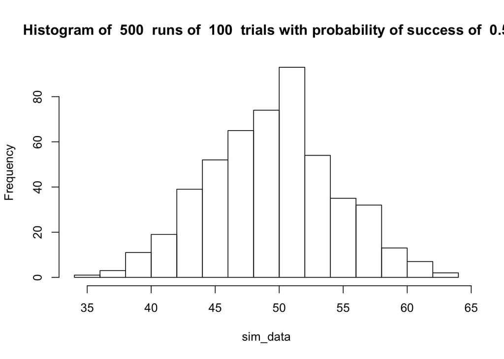

```
## [1] "Minimum of simulation data:"
```

```
## [1] 35
```

```
## [1] "Maximum of simulation data:"
```

```
## [1] 63
```

In this case, we have a probability of success of $0.5$ with $100$ trials—even odds between success and failure. Even though we expect $50$ successes, we have as few as $35$ and as many as $63$.

We will not go deep into the binomial distribution, though it is very useful. What we are interested in is estimating the value $p$, which we don’t know, in the context of binary or count data. We typically have either a count of all events summarized in a table (e.g. in the form of a [contingency table](https://en.wikipedia.org/wiki/Contingency_table)) or as a list of binary events (e.g. survival data with associated variables like drug treatment, sex, age, etc).

## Logistic regression

Assume that we have binary outcome data ($y$) and explanatory variables ($\mathbf{x}$) for each observation. Each observation is a Bernoulli trial where $y=1$ with a probability $\pi$ and $y=0$ with a probability $(1-\pi)$. Each observation is a **Bernoulli trial**. We believe that the probability of success ($y=1$) is related to $x$, so we write $\pi$ as $\pi(x)$. Since we have many Bernoulli trials, which we assume are independent, our data follow the Binomial distribution.

Like with linear regression, we have $n$ observations and $p$ covariates. An individual observation is called a **case**, and when all explanatory covariates match among cases, we call it a **constellation** (personal note: I haven’t heard this term used often—I’ve heard “class”, “group”, “crosstab”, etc). Some examples:

- Survival data ($y=1$ if a patient lived, $y=0$ if they died) by sex ($x_1=1$ for male, $x_1=0$ for female) and treatment ($x_2=1$ for treatment, $x_2=0$ for placebo)
- Vaccine data ($y=1$ if a patient becomes infected) by vaccination status ($x_1=1$ if they were vaccinated)

We write the explanatory variables as $\mathbf{x}=(x_{1},x_{2},\dots,x_{p})'$, and our function of the probability of success as $\pi=\pi(\mathbf{x}_i)$.

The specifics of the notation (i.e. subscripts) will change depending on how the problem is formulated, but generally our binomial probability looks like this:

$$P(Y=y) = {n \choose y}[\pi(\mathbf{x})]^{y}[1-\pi(\mathbf{x})]^{n-y}$$
We are interested in estimating $\pi(\mathbf{x})$; we wish to link the probability $\pi$ to the covariates $\mathbf{x} = x_1, \dots, x_p$. We do this by selecting a **link function**. We would like a function in which:

- $\pi$ depends on $\mathbf{x}$ in a linear manner, because linear functions have nice properties
- $\pi$ falls within the values $[0,1]$, since it is a probability.

There are many link functions. We will use the **logistic function** or the **logit**. It takes the form:

$$\pi(\mathbf{x}) = \frac{1}{1 + e^{-\mathbf{x}'\mathbf{\beta}}}$$

It looks like this:

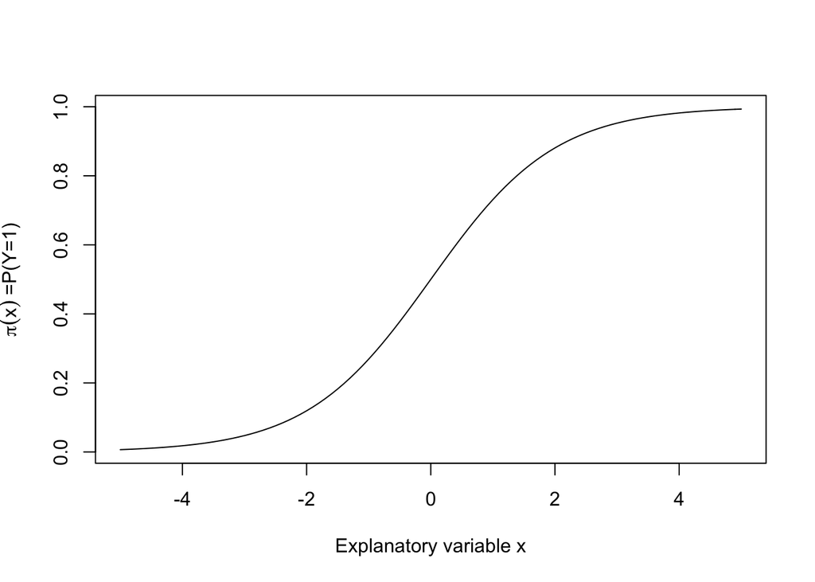

```r
curve(1/(1+exp(-x)), from=-5, to=5,  xlab="Explanatory variable x", ylab=expression(pi(x)~"=P(Y=1)"))
```

There are other link functions, such as the probit, complementary log-log (cloglog), the log-log, etc. The logit has some nice properties:

- It is symmetric
- It has simpler theoretical properties
- It is easier to interpret as the log of odds ratios
- It can be used in estimates either prospectively or retrospectively

## Interpreting logistic regression

Through some algebra, we can re-arrange the logit equation to get:

$$\ln\frac{\pi(\mathbf{x})}{1-\pi(\mathbf{x})} = \mathbf{x}'\mathbf{\beta} = \beta_0 + \beta_1x_1 + ... + \beta_px_p$$
Here $\frac{\pi(\mathbf{x})}{1- \pi(\mathbf{x})}$ is our **log-odds**. We can also exponentiate both sides to get our **odds**:

$$\frac{\pi(\mathbf{x})}{1-\pi(\mathbf{x})} = \exp(\mathbf{x}'\mathbf{\beta}) = \exp(\beta_0 + \beta_1x_1 + ... + \beta_px_p)$$
The odds are the ratio of the probability of something happening versus not happening. If $\pi=0.5$, both events are equally likely and the odds are $1$. If the probability is higher, then the odds will be greater than $1$; if it is lower, the odds are below $1$. For example, if $\pi=0.75$, then our ratio is $0.75/0.25 = 3$.

Often we are interested in how a change in the explanatory variables impacts the value of $\pi$. Usually we do this by keeping all variables fixed and incrementing one of them. For illustration, assume we have a simple case with two groups: those who received a drug (indicated with $i=1$), and those who did not (indicated with $i=0$). We are interested in $\pi_i$, the probability of survival of each group.

Our logistic regression model is:

$$\log(\frac{\pi_i}{1-\pi_i}) = \beta_0 + \beta_1x_{i1}, \text{ for groups } i=\{0,1\}$$

If someone did not receive a drug, then we have:

$$\begin{aligned}
&\log(\frac{\pi_0}{1-\pi_0}) \\
&= \beta_0 + \beta_1(0) \\
&= \beta_0
\end{aligned}$$

If they did, then we have:

$$\log(\frac{\pi_1}{1-\pi_1}) = \beta_0 + \beta_1$$

We can compare these two and use some algebra of logarithms to get our log odds ratio:

$$\begin{aligned}
& \log(\frac{\pi_1}{1-\pi_1}) - \log(\frac{\pi_0}{1-\pi_0}) \\
&=\log(\frac{\pi_1/(1-\pi_1)}{\pi_0/(1-\pi_0)}) \\
&= (\beta_1 + \beta_0) - \beta_0 \\
&= \beta_1 \\
\end{aligned}$$
In this case, $\beta_1$ is the log-odds ratio of survival for those given the drug versus not given the drug. To calculate the odds radio, we use $\exp(\beta_1)$. **We are usually most interested in this type of analysis**.

Finally, we can re-arrange everything to get our **probability of success**:

$$\pi(\mathbf{x}) = \frac{\exp(\beta_0 + \beta_1x_1 + ... + \beta_px_p)}{1 + \exp(\beta_0 + \beta_1x_1 + ... + \beta_px_p)}$$

Unlike odds, this value gives us the direct interpretation of how likely something is to happen. This can be useful to give more meaning to a rare event that may become more likely through a higher odds ratio.

For brevity, we will omit the derivations of various estimators. We use similar notation to linear regression, where $\hat{\beta}$ represents the estimate of $\beta$.

## The `glm` function

Logistic regression in R is done with the `glm` function. Its syntax and output are similar to the `lm` function, although we have to specify the family and link function. In this case, we will use the `binomial` family and `logit` link function. The typical setup is:

`model.name <- glm(RESPONSE ~ COVARIATES, family = binomial(link=logit), data = dataframename)`

As with linear regression, we can use the `summary` function, as well as `predict`.

### Example

Consider a toy example where we simulate two populations: one that is given a drug that increases the chance of survival, and another that is given a placebo, which has a low chance of survival.

```r
# Simulate a study where 50 people are given a drug and 50 people are given a placebo
# Those given the treatment have a 70% chance of survival
# Those given the placebo have a 20% chance of survival
# We randomly draw values of 1/0 from the binomial distribution
# Here, 1 indicates survival and 0 indicates death
set.seed(20230317)

pop1_size <- 50
pop2_size <- 50

pop_place <- rbinom(pop1_size,1,0.2)
pop_treat <- rbinom(pop2_size,1,0.7)

pop_sim <- data.frame(c(rep("placebo",pop1_size),rep("drug",pop2_size)),c(pop_place, pop_treat))
colnames(pop_sim) <- c("treatment","survived")

sim_glm <- glm(survived ~ treatment, family = binomial(link="logit"), data = pop_sim)
```

```r
summary(sim_glm)
```

```
##
## Call:
## glm(formula = survived ~ treatment, family = binomial(link = "logit"),
##     data = pop_sim)
##
## Deviance Residuals:
##     Min       1Q   Median       3Q      Max
## -1.8519  -0.7049   0.6300   0.6300   1.7402
##
## Coefficients:
##                  Estimate Std. Error z value Pr(>|z|)
## (Intercept)        1.5163     0.3681   4.119  3.8e-05 ***
## treatmentplacebo  -2.7820     0.5020  -5.541  3.0e-08 ***
## ---
## Signif. codes:  0 '***' 0.001 '**' 0.01 '*' 0.05 '.' 0.1 ' ' 1
##
## (Dispersion parameter for binomial family taken to be 1)
##
##     Null deviance: 138.47  on 99  degrees of freedom
## Residual deviance:  99.83  on 98  degrees of freedom
## AIC: 103.83
##
## Number of Fisher Scoring iterations: 4
```

```r
#confint(sim_glm)
#exp(confint(sim_glm))

# The values of our betas
#beta_0 <- summary(sim_glm)$coefficients[1,1]
#beta_1 <- summary(sim_glm)$coefficients[2,1]

# Our odds of survival for the placebo:
#print(paste("Odds of survival for placebo",exp(beta_0 + beta_1)))

# Our odds of survival for the drug:
#print(paste("Odds of survival for treatment",exp(beta_0)))

# Find the probability of survival for the placebo:
#print(paste("Probability of survival for placebo",(exp(beta_0 + beta_1)/(1 + exp(beta_0 + beta_1)))))

# Find the probability of survival for the treatment:
#print(paste("Probability of survival for treatment",exp(beta_0)/(1 + exp(beta_0))))

# Test the
#anova(sim_glm, test = "Chisq")
#with(sim_glm, pchisq(null.deviance - deviance, df.null - df.residual, lower.tail = FALSE))
```

There are a few things to note when comparing this output to that of linear regression:

- We have a z-statistic instead of a t-statistic like in linear regression
- We do not have an $R^2$ value or F-statistic, but instead null and residual deviances
- We also have an AIC

We can reformat this data to fit a contingency table:

```r
pop_sim_cont <- data.frame(table(pop_sim)) # Aggregate our data into counts

# Get our marginal counts.
# We know we have 50 of each but it's good practice for coding
total_drug <- sum(pop_sim_cont[pop_sim_cont["treatment"]=="drug",]$Freq)
total_plac <- sum(pop_sim_cont[pop_sim_cont["treatment"]=="placebo",]$Freq)

# Drop our death observations and attach the counts we just got instead
pop_sim_cont <- subset(pop_sim_cont, survived==1)
pop_sim_cont$survived <- pop_sim_cont$Freq # Set the variable "survived" to a count
pop_sim_cont <- pop_sim_cont[,c(1,2)]
pop_sim_cont$patients <-with(pop_sim_cont,
                             ifelse(treatment=="drug", total_drug, total_plac))

# Add a variable of the response (the number of survived vs died)
pop_sim_cont$resp <- cbind(pop_sim_cont$survived, pop_sim_cont$patients - pop_sim_cont$survived)
```

Now that our data is formatted as a contingency table, we can run the same analysis:

```r
sim_glm_cont <- glm(resp ~ treatment, family = binomial(link = "logit"), data = pop_sim_cont)
summary(sim_glm_cont)
```

```
##
## Call:
## glm(formula = resp ~ treatment, family = binomial(link = "logit"),
##     data = pop_sim_cont)
##
## Deviance Residuals:
## [1]  0  0
##
## Coefficients:
##                  Estimate Std. Error z value Pr(>|z|)
## (Intercept)        1.5163     0.3681   4.119  3.8e-05 ***
## treatmentplacebo  -2.7820     0.5020  -5.541  3.0e-08 ***
## ---
## Signif. codes:  0 '***' 0.001 '**' 0.01 '*' 0.05 '.' 0.1 ' ' 1
##
## (Dispersion parameter for binomial family taken to be 1)
##
##     Null deviance: 3.8639e+01  on 1  degrees of freedom
## Residual deviance: 4.8850e-15  on 0  degrees of freedom
## AIC: 11.859
##
## Number of Fisher Scoring iterations: 3
```

### Haberman data

We will use Haberman’s survival data.[^1] It is a record of breast cancer patients who underwent surgery. The attributes are:

1. Age of patient at time of operation (numerical)
2. Patient’s year of operation (year - 1900, numerical)
3. Number of positive axillary nodes detected (numerical)
4. Survival status (class attribute)

1 = the patient survived 5 years or longer  
2 = the patient died within 5 years

```r
haberman.data <- read.csv("haberman.data", header=F)
colnames(haberman.data) <- c("age","surgery_year","nodes","survival_status")

# recode the survival status to 1 (lived 5+ years)  and 0 (died within 5 years)
haberman.data$survival_status <- ifelse(haberman.data$survival_status==2,0,1)
```

The first thing we may be interested in is plotting our data.

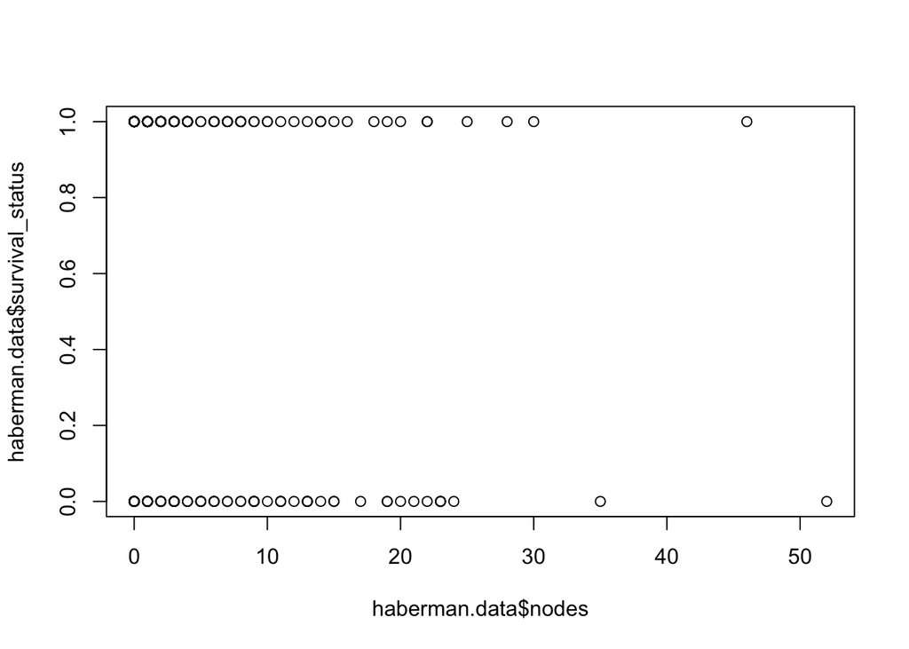

```r
plot(haberman.data$nodes, haberman.data$survival_status)
```

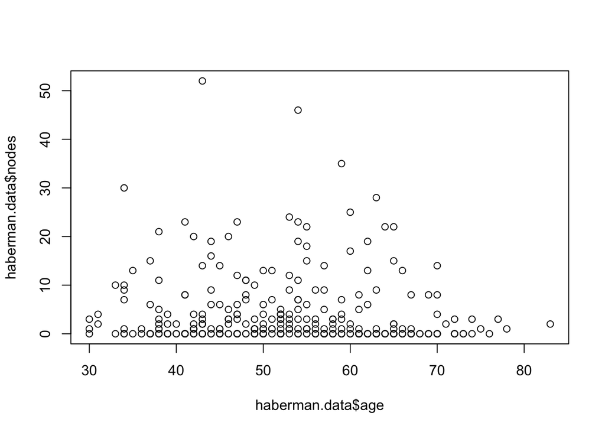

```r
plot(haberman.data$age, haberman.data$nodes)
```

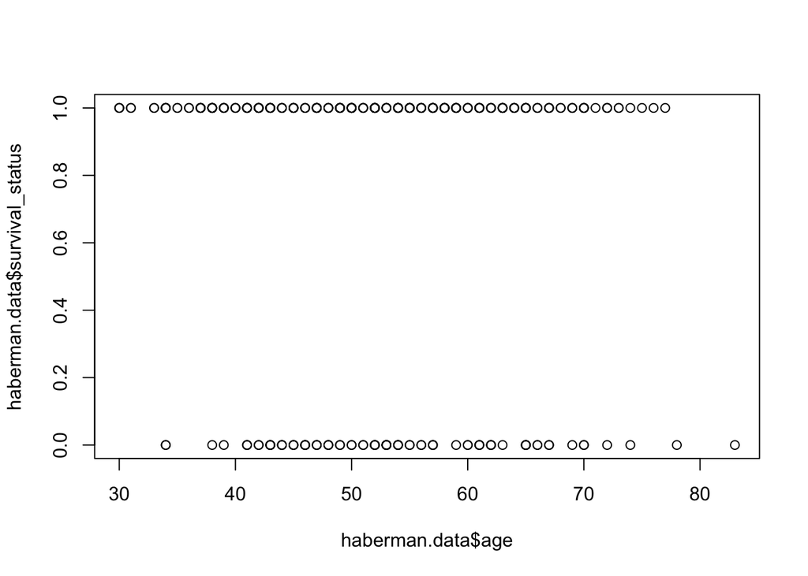

```r
plot(haberman.data$age, haberman.data$survival_status)
```

#### Exercises:

Create a logistic model in R that models survival status against each of the variables in the data

```r
#haberman.model1 <- glm(...,
#                       family=binomial(link = "logit"),
#                       data = haberman.data)

#summary(haberman.model1)
```

```r
#plot(haberman.data$nodes, haberman.data$survival_status, xlim = c(0,60))

#newdata <- data.frame(nodes=seq(min(haberman.data$nodes), max(haberman.data$nodes),len=500))
#newdata$pred = predict(haberman.model1, newdata, type="response")

#lines(pred ~ nodes, newdata)
```

### Exercises: Other datasets

The following data are available in the `Sleuth3` package, which you can install using `install.packages("Sleuth3")`:

- `Sleuth3::case2001`: In 1846 the Donner and Reed families left Springfield, Illinois, for California by covered wagon. In July, the Donner Party, as it became known, reached Fort Bridger, Wyoming. There its leaders decided to attempt a new and untested rote to the Sacramento Valley. Having reached its full size of 87 people and 20 wagons, the party was delayed by a difficult crossing of the Wasatch Range and again in the crossing of the desert west of the Great Salt Lake. The group became stranded in the eastern Sierra Nevada mountains when the region was hit by heavy snows in late October. By the time the last survivor was rescued on April 21, 1847, 40 of the 87 members had died from famine and exposure to extreme cold.
- `Sleuth3::case2002`: A 1972–1981 health survey in The Hague, Netherlands, discovered an association between keeping pet birds and increased risk of lung cancer. To investigate birdkeeping as a risk factor, researchers conducted a case–control study of patients in 1985 at four hospitals in The Hague (population 450,000). They identified 49 cases of lung cancer among the patients who were registered with a general practice, who were age 65 or younger and who had resided in the city since 1965. They also selected 98 controls from a population of residents having the same general age structure.
[^1]: Dua, D. and Graff, C. (2019). UCI Machine Learning Repository [http://archive.ics.uci.edu/ml]. Irvine, CA: University of California, School of Information and Computer Science.